# Radviz Sat Oct 14 23, 18:59:52

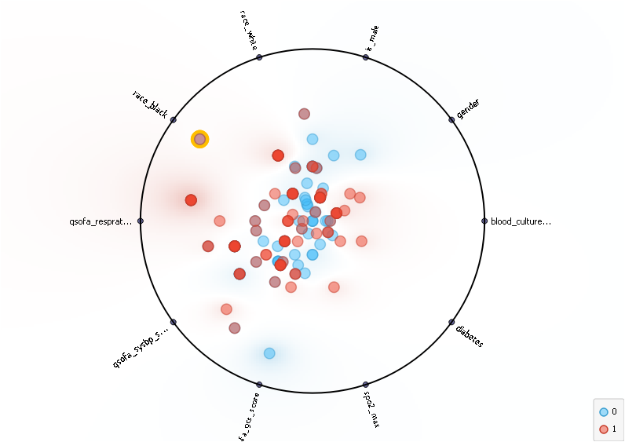

**Color**: hospital_expire_flag

# Correlations Sat Oct 14 23, 19:05:04

## Pearson correlation

| 1 | +1.000 | icustay_id | icustay_id.1 |
| --- | --- | --- | --- |
| 2 | +1.000 | sepsis_explicit=1 | severe_sepsis_explicit=1 |
| 3 | +1.000 | gender=M | is_male=1 |
| 4 | +1.000 | hadm_id | hadm_id.1 |
| 5 | +1.000 | blood_culture_time | suspected_infection_time_poe |
| 6 | +1.000 | blood_culture_time | intime |
| 7 | +1.000 | intime | suspected_infection_time_poe |
| 8 | +1.000 | antibiotic_time_poe | suspected_infection_time_poe |
| 9 | +1.000 | antibiotic_time_poe | blood_culture_time |
| 10 | +1.000 | antibiotic_time_poe | intime |
| 11 | +1.000 | antibiotic_time_poe | outtime |
| 12 | +1.000 | outtime | suspected_infection_time_poe |
| 13 | +1.000 | blood_culture_time | outtime |
| 14 | +1.000 | intime | outtime |
| 15 | +1.000 | glucose_max1 | glucose_mean |
| 16 | +0.988 | bun_max | bun_mean |
| 17 | +0.986 | wbc_max | wbc_mean |
| 18 | +0.983 | bun_mean | bun_min |
| 19 | +0.976 | ethnicity=WHITE | race_white=1 |
| 20 | +0.972 | wbc_mean | wbc_min |
| 21 | +0.967 | hematocrit_max | hemoglobin_max |
| 22 | +0.966 | lactate_max | lactate_mean |
| 23 | +0.964 | hematocrit_min | hemoglobin_min |
| 24 | +0.946 | bun_max | bun_min |
| 25 | +0.922 | wbc_max | wbc_min |
| 26 | +0.919 | ethnicity=BLACK/AFRICAN AMERICAN | race_black=1 |
| 27 | +0.917 | platelet_max | platelet_min |
| 28 | +0.915 | creatinine_max | creatinine_min |
| 29 | +0.869 | diasbp_mean | meanbp_mean |
| 30 | +0.859 | tempc_max | tempc_mean |
| 31 | +0.855 | heartrate_max | heartrate_mean |

[output cut: 70 more lines]

# SVM Sat Oct 14 23, 19:26:14

**Name:** SVM (1)

## Model parameters

**SVM type:** SVM, C=1.0, ε=0.1  
**Kernel:** Polynomial, (auto x⋅y + 1.0)<sup>3</sup>  
**Numerical tolerance:** 0.001  
**Iteration limt:** 100

## Data

**Data instances:** 1  
**Features:** icustay_id, hadm_id, intime, outtime, dbsource, suspected_infection_time_poe, suspected_infection_time_poe_days, specimen_poe, antibiotic_time_poe, blood_culture_positive, blood_culture_time, gender, age, is_male, ethnicity, race_white, race_black, race_hispanic, race_other, diabetes, first_service, sepsis_angus, sepsis_martin, sepsis_explicit, septic_shock_explicit, severe_sepsis_explicit, sepsis_nqf, sepsis_cdc, sepsis_cdc_simple, vent, elixhauser_hospital, sofa, lods, sirs, qsofa_sysbp_score, qsofa_gcs_score, qsofa_resprate_score, aniongap_min, aniongap_max, bicarbonate_min, bicarbonate_max, creatinine_min, creatinine_max, chloride_min, chloride_max, glucose_min, glucose_max, hematocrit_min, hematocrit_max, hemoglobin_min, hemoglobin_max, lactate_min, lactate_max, lactate_mean, platelet_min, platelet_max, potassium_min, potassium_max, inr_min, inr_max, sodium_min, sodium_max, bun_min, bun_max, bun_mean, wbc_min, wbc_max, wbc_mean, heartrate_min, heartrate_max, heartrate_mean, ... (total: 99 features)  
**Meta attributes:** metastatic_cancer, hosp_los, icu_los, positiveculture_poe, qsofa  
**Target:** hospital_expire_flag